# Melding Experiment

# Formulas for Reference

- $\alpha$ and $\beta$:
  - $P(+|S_1,untested) = \alpha P(test + | tested)$
  - $P(+|S_0, untested) = \beta P(test + | tested)$
- Positives among symptom categories:
  - $N^+_{untested,S_0} = N_{untested} (1-P(S_1|untested)) P(test+|S_0,untested)$
  - $N^+_{untested,S_1} = N_{untested}( P(S_1|untested) ) P(test+|S_1,untested)$
  - $N^+_{untested} = N^+_{untested,S_0} + N^+_{untested,S_1}$
- Total positives
  - $N^+ = N^+_{untested} + N^+_{tested}$
- At this point there is a correction for test inaccuracy, but not relevant here since those things are left the same for all changes.

# Broad Takeaways

- Effect of truncation is really dramatic
  - Particularly true when there is little agreement between the induced and melded priors
- Changes to $\alpha$ have what seems to be a very small effect on the other distributions. This makes sense when we look at the function $M$ given by

$$M(\theta) = P(S_0|test +, untested) =
\dfrac{ \beta (1-P(S_1|untested))} {\beta (1-P(S_1|untested)) +
\alpha P(S_1|untested)}$$
$P(S_1|untested)$ is always very small relative to $P(S_1|untested)$, so changes in alpha don’t have a major impact. The lack of sensitivity to the definition of $\alpha$ is somewhat fortunate because I’m having trouble finding sources to inform the definition of $\alpha$.

- In post melding distributions, we almost always see:
  - $\alpha$ is basically unchanged
  - $\beta$ has more density toward zero
  - $P(S_1|untested)$ has more density higher than it was originally

Next steps for understanding this further…

- It’s one thing to see the differences in the post-melding distributions of the priors, but it’s not immediately obvious how this translates to differences in the actual corrected counts. I think to understand this better I’ll pick a particular county and then see the implications of these changes at the level of the final counts.

# Read Data

```r
# Read Data -----------
state_name <- "ma"
covid_county <- paste0(here::here(),
                          "/data/",
                          state_name,
                          "/",
                          state_name,
                          "_county_biweekly.RDS") %>%
  readRDS()  %>%
  select(-date) %>%
  distinct() %>%
  filter(fips == "25025")

#covid_county <- covid_county[1,]

corrected_original <- readRDS(paste0(here::here(),
               "/melding2/example_county_data/example_county.RDS"))


dates <- readRDS(paste0(here::here(),
                        "/data/date_to_biweek.RDS"))
```

# Base Functions

```r
###############################################################
# BETA PARAMETERS FROM DESIRED MEAN AND VARIANCE
###############################################################
get_beta_params <- function(mu, sd) {
    var = sd^2
    alpha <- ((1 - mu) / var - 1 / mu) * mu ^ 2
    beta <- alpha * (1 / mu - 1)
    return(params = list(alpha = alpha,
                         beta = beta))
}




###############################################################
# BETA DENSITY WITH DESIRED MEAN AND VARIANCE
###############################################################
beta_density <- function(x, mean, sd, bounds=NA) {
    shape_params <-  get_beta_params(
        mu = mean,
        sd = sd)

    if(!length(bounds) == 1){
        # message("here")
        dtrunc(x,
               spec = "beta",
               a = bounds[1],
               b = bounds[2],
              shape1 = shape_params$alpha,
              shape2 = shape_params$beta) %>%
            return()
    }else{
        dbeta(x,
          shape1 = shape_params$alpha,
          shape2 = shape_params$beta)  %>%
            return()
        }
}




###############################################################
# SAMPLE FROM BETA DENSITY WITH DESIRED MEAN AND VARIANCE
###############################################################

sample_beta_density <- function(n, mean, sd, bounds = NA) {

    shape_params <-  get_beta_params(
        mu = mean,
        sd = sd)

    rbeta(n,
          shape1 = shape_params$alpha,
          shape2 = shape_params$beta)

    if(!length(bounds) == 1){
        # message("here")
        rtrunc(n,
               spec = "beta",
               a = bounds[1],
               b = bounds[2],
               shape1 = shape_params$alpha,
               shape2 = shape_params$beta) %>%
            return()
    }else{
        rbeta(n,
              shape1 = shape_params$alpha,
              shape2 = shape_params$beta)  %>%
            return()
    }
}




###############################################################
# GAMMA PARAMETERS FROM DESIRED MEAN AND VARIANCE
###############################################################
get_gamma_params <- function(mu, sd) {
    var = (mu/sd)^2
    shape = (mu/sd)^2
    scale = sd^2/mu
    return(params = list(shape = shape,
                         scale = scale))
}


###############################################################
# GAMMA DENSITY WITH DESIRED MEAN AND VARIANCE
###############################################################
gamma_density <- function(x, mean, sd, bounds=NA) {

    shape_params <-  get_gamma_params(
        mu = mean,
        sd = sd)

    if(!length(bounds) == 1){
        #message("here")
        dtrunc(x,
               spec = "gamma",
               a = bounds[1],
               b = bounds[2],
               shape = shape_params$shape,
               scale = shape_params$scale) %>%
            return()
    }else{
        dgamma(x,
               shape = shape_params$shape,
               scale = shape_params$scale) %>%
            return()
    }
}


sample_gamma_density <- function(n, mean, sd, bounds = NA) {

    shape_params <-  get_gamma_params(
        mu = mean,
        sd = sd)

    if(!length(bounds) == 1){
        #message("here")
        rtrunc(n,
               spec = "gamma",
               a = bounds[1],
               b = bounds[2],
               shape = shape_params$shape,
               scale = shape_params$scale) %>%
            return()
    }else{
        rgamma(n,
               shape = shape_params$shape,
               scale = shape_params$scale) %>%
            return()
    }
}





###############################################################
# INDUCED PRIOR ON ASYMPTOMATIC RATE  P(S_0|test+,untested)
###############################################################

# input sampled values of theta and compute M(\theta)
est_P_A_testpos = function(P_S_untested, alpha, beta){
    (beta * (1 - P_S_untested)) / (( beta * (1 - P_S_untested)) + (alpha * P_S_untested))
}
```

```r
##############################
# ORIGINAL PRIORS
##############################
# alpha_mean = 0.9
# alpha_sd = 0.04
# alpha_bounds = c(.8,1)
# beta_mean = .15
# beta_sd =.09
# beta_bounds = c(0.002, 0.4)
# s_untested_mean = .025
# s_untested_sd = .0225
# s_untested_bounds = c(0, 0.15)
# p_s0_pos_mean = .4
# p_s0_pos_sd = .1225
# p_s0_pos_bounds = c(.25, .7)
# nsamp = 1e4


##############################
# ORIGINAL PRIORS (AS LIST)
##############################
params_original <- list(
  alpha_mean = 0.9,
  alpha_sd = 0.04,
  alpha_bounds = c(.8,1),
  beta_mean = .15,
  beta_sd =.09,
  beta_bounds = c(0.002, 0.4),
  s_untested_mean = .025,
  s_untested_sd = .0225,
  s_untested_bounds = c(0, 0.15),
  p_s0_pos_mean = .4,
  p_s0_pos_sd = .1225,
  p_s0_pos_bounds = c(.25, .7),
  nsamp = 1e5)
```

```r
##########################################
# County Correction Functions -----------
##########################################


#' Add sensitivity and specificity
process_priors_per_county <-  function(priors, df){
  dist_Se <- truncdist::rtrunc(n = 1e5,spec = "beta",a = 0.65,b = 1,
                               shape1 = get_beta_params(mu = 0.8,
                                                        sd = (0.4)^2)$alpha,
                               shape2 = get_beta_params(mu = 0.8,
                                                        sd = (0.4)^2)$beta)
  dist_Sp <- truncdist::rtrunc(n = 1e5,spec = "beta",a = 0.9998,b = 1,
                               shape1 = get_beta_params(mu = 0.99995,
                                                        sd = (0.01)^2)$alpha,
                               shape2 = get_beta_params(mu = 0.99995,
                                                        sd = (0.01)^2)$beta)
  priors_out <- priors %>%
    mutate(
      # calculate P(+|S_1, untested) and P(+|S_0, untested)
      P_testpos_S = priors$Z_S  * df$posrate,
      P_testpos_A = priors$Z_A  * df$posrate,
      empirical_testpos = df$posrate,
      population = df$population,
      total = df$total,
      positive = df$positive,
      negative = df$negative) %>%
    mutate(Se = dist_Se,
           Sp = dist_Sp,
           biweek = df$biweek,
           fips = df$fips) %>%
    # compute with constrained priors
    mutate(P_A_testpos = est_P_A_testpos(
      P_S_untested = priors$P_S_untested,
      alpha = priors$Z_S,
      beta = priors$Z_A))
  return(priors_out)
}


#' correct for test inaccuracy
calc_A_star <- function(N, N_tested,
                        N_pos_obs,
                        P_testpos_est,
                        P_S_untested,
                        P_A_testpos,
                        Z_S,
                        Z_A,
                        Se,
                        Sp){

  N_untested = N - N_tested

  # number symptomatic and asymptomatic among tested
  Npos_tested_S = N_pos_obs * (1 - P_A_testpos)
  Npos_tested_A = N_pos_obs - Npos_tested_S

  #  prob testpos among untested
  P_testpos_S = P_testpos_est * Z_S
  P_testpos_A = P_testpos_est * Z_A

  # estimate number of positives among untested
  Npos_untested_S = P_S_untested * N_untested * P_testpos_S
  Npos_untested_A = (1 - P_S_untested) * N_untested * P_testpos_A

  A_star = Npos_tested_S   + Npos_tested_A +
    Npos_untested_S + Npos_untested_A

  # correct for imperfect sensitivity and specificity
  A = (A_star - ((1 - Sp) * N)) / (Se + Sp - 1)

  return(max(A,0))

}

#' compute corrected counts for randomly sampled combination of parameters
correct_bias <- function(priors_by_county_df){
  # N, N_tested, N_pos_obs, P_testpos_est,

  # sample index to draw from distribution
  sample_ind = sample(1:nrow(priors_by_county_df),
                      size = 1,
                      replace=TRUE)

  # randomly sample from each distribution
  sampled_priors = priors_by_county_df[sample_ind,]

  # corrected case count
  Astar = calc_A_star(N = sampled_priors$population,
                      N_tested =sampled_priors$total,
                      N_pos_obs = sampled_priors$positive,
                      P_testpos_est = sampled_priors$empirical_testpos,
                      P_S_untested = sampled_priors$P_S_untested,
                      P_A_testpos = sampled_priors$P_A_testpos,
                      Z_S = sampled_priors$Z_S,
                      Z_A = sampled_priors$Z_A,
                      Se = sampled_priors$Se,
                      Sp = sampled_priors$Sp
  )

  out = cbind(sampled_priors, exp_cases=Astar)

  return(out)
}


#' generate distribution of corrected counts
generate_corrected_sample = function(priors_by_county_df,
                                     num_reps){

  # Obtain corrected case estimates
  reps = num_reps

  # need to set seed here to ensure that the same random draws are
  # used for a given time period / location with same priors
  set.seed(123)

  # perform probabilistic bias analysis
  result = replicate(reps, correct_bias(priors_by_county_df ), simplify=FALSE) %>%
    bind_rows()

  return(result)

}


#' summarize distribution of corrected counts
summarize_corrected_sample <- function(priors_by_county_df_exp_cases) {

  summarized <-  tibble(
    exp_cases_median = median(priors_by_county_df_exp_cases$exp_cases),
    exp_cases_lb = quantile(priors_by_county_df_exp_cases$exp_cases,
                            prob = 0.025) %>% unlist(),
    exp_cases_ub = quantile(priors_by_county_df_exp_cases$exp_cases,
                            prob = 0.975) %>% unlist(),
    biweek = unique(priors_by_county_df_exp_cases$biweek),
    fips = unique(priors_by_county_df_exp_cases$fips),
    empirical_testpos = unique(priors_by_county_df_exp_cases$empirical_testpos),
    population = unique(priors_by_county_df_exp_cases$population),
    negative = unique(priors_by_county_df_exp_cases$negative),
    positive = unique(priors_by_county_df_exp_cases$positive),
    total = unique(priors_by_county_df_exp_cases$total))

  return(summarized)

}


get_corrected_counts <- function(county_df, melded_df) {

  melded_df <- melded_df %>%
    rename(Z_S = alpha,
           Z_A = beta)

  corrected <- pmap_df(county_df, ~ {
    process_priors_per_county(
      priors = melded_df,
      df = list(...)) %>%
      generate_corrected_sample(., num_reps = 1e3) %>%
      summarize_corrected_sample() })

  corrected %>%
    left_join(dates)
}
```

```r
get_melded <- function(alpha_mean = 0.9,
                       alpha_sd = 0.04,
                       alpha_bounds = NA,
                       beta_mean = .15,
                       beta_sd =.09,
                       beta_bounds = NA,
                       s_untested_mean = .025,
                       s_untested_sd = .0225,
                       s_untested_bounds = NA,
                       p_s0_pos_mean = .4,
                       p_s0_pos_sd = .1225,
                       p_s0_pos_bounds = NA,
                       nsamp = 1e3) {

  given_args <- as.list(environment())
  # cat("Arguments to get_melded:\n")
  # print(given_args)

    theta <- tibble(alpha = sample_gamma_density(nsamp,
                                                mean = alpha_mean,
                                                sd = alpha_sd,
                                                bounds = alpha_bounds),
                    beta= sample_beta_density(nsamp,
                                              mean = beta_mean,
                                              sd = beta_sd,
                                              bounds = beta_bounds),
                    P_S_untested = sample_beta_density(nsamp,
                                                       mean = s_untested_mean,
                                                       sd = s_untested_sd,
                                                       bounds = s_untested_bounds)) %>%
        mutate(phi_induced = est_P_A_testpos(P_S_untested = P_S_untested,
                                             alpha = alpha,
                                             beta=beta))

    # theta contains values sampled from alpha, beta, P_S_untested, and M(theta) = phi_induced
    # induced phi
    phi <- theta$phi_induced

    # approximate induced distribution via a density approximation
    phi_induced_density <- density(x = phi, n = nsamp, adjust = 2, kernel = "gaussian")

    indexes <- findInterval(phi, phi_induced_density$x)

    phi_sampled_density <- phi_induced_density$y[indexes]

    dp_s0_pos <- function(x) {

      beta_density(x,
                   mean=p_s0_pos_mean,
                   sd = p_s0_pos_sd,
                   bounds=p_s0_pos_bounds)
    }

    weights <- (phi_sampled_density/ dp_s0_pos(phi))^(.5)

    post_samp_ind <-sample.int(n=nsamp,
                               size=nsamp,
                               prob=1/weights,
                               replace=TRUE)

    pi_samp <- cbind(theta[post_samp_ind,],
                     P_A_testpos =  phi[post_samp_ind]) %>%
        select(-phi_induced)

    return(list(post_melding = pi_samp, pre_melding = theta))

}


#' reformat for plot generation
reformat_melded <- function(melded_df,
                            theta_df,
                            nsamp,
                            p_s0_pos_mean,
                            p_s0_pos_sd,
                            p_s0_pos_bounds) {

  melded_df_long <- melded_df %>%
    pivot_longer(cols=everything()) %>%
    mutate(type = "After Melding")


  melded <- theta_df %>%
    mutate(P_A_testpos = sample_beta_density(nsamp,
                                             mean = p_s0_pos_mean,
                                             sd = p_s0_pos_sd,
                                             bounds = p_s0_pos_bounds)) %>%
    pivot_longer(cols=everything()) %>%
    mutate(type = ifelse(
      name == "phi_induced",
      "Induced", "Before Melding")) %>%
    mutate(name = ifelse(name == "phi_induced",
                         "P_A_testpos",
                         name)) %>%
    bind_rows(melded_df_long) %>%
    mutate(name = case_when(
      name == "alpha" ~"$\\alpha$",
      name == "beta" ~"$\\beta$",
      name == "P_A_testpos" ~ "$P(S_0|test+,untested)$",
      name == "P_S_untested" ~ "$P(S_1|untested)$")
    ) %>%
    mutate(name = factor(name,
                         levels = c(
                           "$\\alpha$",
                           "$\\beta$",
                           "$P(S_1|untested)$",
                           "$P(S_0|test+,untested)$")))

}
```

```r
get_melded <- function(alpha_mean = 0.9,
                       alpha_sd = 0.04,
                       alpha_bounds = NA,
                       beta_mean = .15,
                       beta_sd =.09,
                       beta_bounds = NA,
                       s_untested_mean = .025,
                       s_untested_sd = .0225,
                       s_untested_bounds = NA,
                       p_s0_pos_mean = .4,
                       p_s0_pos_sd = .1225,
                       p_s0_pos_bounds = NA,
                       nsamp = 1e5) {

  given_args <- as.list(environment())
  cat("Arguments to get_melded:\n")
  print(given_args)

    theta <- tibble(alpha = sample_gamma_density(nsamp,
                                                mean = alpha_mean,
                                                sd = alpha_sd,
                                                bounds = alpha_bounds),
                    beta= sample_beta_density(nsamp,
                                              mean = beta_mean,
                                              sd = beta_sd,
                                              bounds = beta_bounds),
                    P_S_untested = sample_beta_density(nsamp,
                                                       mean = s_untested_mean,
                                                       sd = s_untested_sd,
                                                       bounds = s_untested_bounds)) %>%
        mutate(phi_induced = est_P_A_testpos(P_S_untested = P_S_untested,
                                             alpha = alpha,
                                             beta=beta))

    # theta contains values sampled from alpha, beta, P_S_untested, and M(theta) = phi_induced
    # induced phi
    phi <- theta$phi_induced

    # approximate $q_1^*(\phi)$ via a density approximation
    phi_induced_density <- density(x = phi, n = nsamp, adjust = 2, kernel = "gaussian")


    indexes <- findInterval(phi, phi_induced_density$x)

    phi_sampled_density <- phi_induced_density$y[indexes]

    dp_s0_pos <- function(x) {

      beta_density(x,
                   mean=p_s0_pos_mean,
                   sd = p_s0_pos_sd,
                   bounds=p_s0_pos_bounds)
    }

    weights <- (phi_sampled_density/ dp_s0_pos(phi))^(.5)

    post_samp_ind <-sample.int(n=nsamp,
                               size=nsamp,
                               prob=1/weights,
                               replace=TRUE)

    pi_samp <- cbind(theta[post_samp_ind,],
                     P_A_testpos =  phi[post_samp_ind]) %>%
        select(-phi_induced)

    pi_samp_long <- pi_samp %>%
        pivot_longer(cols=everything()) %>%
        mutate(type = "After Melding")

    melded <- theta %>%
        mutate(P_A_testpos = sample_beta_density(nsamp,
                                                 mean = p_s0_pos_mean,
                                                 sd = p_s0_pos_sd,
                                                 bounds = p_s0_pos_bounds)) %>%
        pivot_longer(cols=everything()) %>%
        mutate(type = ifelse(
            name == "phi_induced",
            "Induced", "Before Melding")) %>%
        mutate(name = ifelse(name == "phi_induced",
                             "P_A_testpos",
                             name)) %>%
        bind_rows(pi_samp_long) %>%
        mutate(name = case_when(
            name == "alpha" ~"$\\alpha$",
            name == "beta" ~"$\\beta$",
            name == "P_A_testpos" ~ "$P(S_0|test+,untested)$",
            name == "P_S_untested" ~ "$P(S_1|untested)$")
        ) %>%
        mutate(name = factor(name,
                             levels = c(
                                 "$\\alpha$",
                                 "$\\beta$",
                                 "$P(S_1|untested)$",
                                 "$P(S_0|test+,untested)$")))

    return(melded)

}
```

```r
plot_melded <- function(melded, custom_title="", nsamp) {


  p1 <- melded %>%
    filter(name != "$P(S_0|test+,untested)$") %>%
    ggplot(aes(x = value, fill = type)) +
    geom_density(alpha = .5, show.legend=FALSE) +
    facet_wrap(~name,
               labeller = as_labeller(
                 TeX,   default = label_parsed),
               ncol = 3,
               scales = "fixed") +
    theme_bw() +
    theme(
          # axis.text.y = element_blank(),
          # axis.ticks.y = element_blank(),
          axis.title = element_text(size = 18),
          axis.text.x = element_text(size = 10),
          plot.title =element_text(size = 18,
                                   margin =margin(0,0, .5,0, 'cm')),
          strip.text = element_text(size = 16),
          legend.text = element_text(size = 16)) +
    labs(title = TeX(custom_title,bold=TRUE),
         subtitle =paste0("Number of Samples: ", nsamp),
         fill = "",
         y = "Density") +
    scale_fill_manual(values = c("#5670BF", "#418F6A","#B28542")) +
    guides(fill = guide_legend(keyheight = 2,  keywidth = 2))

  p2 <- melded %>%
    filter(name == "$P(S_0|test+,untested)$") %>%
    ggplot(aes(x = value, fill = type)) +
    geom_density(alpha = .5) +
    facet_wrap(~name,
               labeller = as_labeller(
                 TeX,   default = label_parsed),
               ncol = 3,
               scales = "fixed") +
    theme_bw() +
    theme(
          # axis.text.y = element_blank(),
          # axis.ticks.y = element_blank(),
          axis.title = element_text(size = 18),
          axis.text.x = element_text(size = 10),
          plot.title =element_text(size = 18,
                                   margin =margin(0,0, .5,0, 'cm')),
          strip.text = element_text(size = 16),
          legend.text = element_text(size = 18)) +
    labs(
      #title = paste0("Number of Samples: ", nsamp),
         fill = "",
         y = "Density") +
    scale_fill_manual(values = c("#5670BF", "#418F6A","#B28542")) +
    guides(fill = guide_legend(keyheight = 2,  keywidth = 2)) +
    xlim(0,1)


  p1 / p2 +  plot_layout(nrow =2, widths = c(4,1))



  #  +
 #   scale_x_continuous(n.breaks = 5, limits = c(0,input$alpha_mean + .2))


}



plot_corrected <- function(corrected_df) {

  corrected_original  %>%
    bind_rows(corrected_df) %>%
    ggplot(aes(x = date,
               ymin = exp_cases_lb,
               ymax= exp_cases_ub,
               fill = version)) +
    geom_ribbon(alpha = .6) +
    labs(x = "Date",
         y = "Estimated Total Cases\nfor 2-week Interval",
         fill = "",
         title = "Corrected Estimates for Suffolk County") +
    theme_bw() +
    theme(axis.text.x = element_text(angle = 30,
                                     vjust = .5,
                                     size = 12),
          axis.title = element_text(size = 16,
                                    face = "bold"),
          legend.text = element_text(size = 16),
          legend.position = "right",
          plot.title = element_text(face = "bold",
                                    hjust = .5,
                                    size =22)) +
    scale_y_continuous(labels = scales::comma) +
    scale_x_date(date_breaks = "2 months", date_labels = "%b %Y") +
    scale_fill_manual(values = c("#C94136", "#4297F8")) +
    guides(fill = guide_legend(keyheight = 2, keywidth = 2))


}
```

# Effect of Changing Means

## Changing the Mean of $\alpha$

All parameters left as the original except for $\alpha$, left untruncated for simplicity of changing the mean.

$(\alpha) \cdot P(test +|tested) = P(test + | S_1, untested)$

Observations:

- Setting the mean of $\alpha$ higher leads to an induced distribution with less density toward 1
- In the final corrected estimates, as we expect, changing the mean of $\alpha$ to be higher corresponds to higher adjusted estimates.
  - The effect seems to be substantially larger for the upper bound than the lower bound
    - I think this may be because even if all the values of $\alpha$ are large, if $P(S_1|untested)$ is very near zero, $\alpha P(S_1|untested)$ will be near zero, which means the minimum number of cases would be observed + untested asymptomatic

```r
params_original <- list(
  alpha_mean = 0.9,
  alpha_sd = 0.04,
  # alpha_bounds = c(.8,1),
  alpha_bounds = NA,
  beta_mean = .15,
  beta_sd =.09,
  beta_bounds = c(0.002, 0.4),
  s_untested_mean = .025,
  s_untested_sd = .0225,
  s_untested_bounds = c(0, 0.15),
  p_s0_pos_mean = .4,
  p_s0_pos_sd = .1225,
  p_s0_pos_bounds = c(.25, .7),
  nsamp = 1e5)


results <- map(seq(.7, 3, by = .2),
     ~ {
       params <- params_original
       params$alpha_mean <- .x
       # print(params)
       melded <- do.call(get_melded, params)

       title <- paste0("Mean of ${\\alpha}$: ", .x)

       melded_long <- reformat_melded(melded_df =  melded$post_melding,
                                      theta_df =  melded$pre_melding,
                                      p_s0_pos_mean = params$p_s0_pos_mean,
                                      p_s0_pos_sd = params$p_s0_pos_sd,
                                      p_s0_pos_bounds = params$p_s0_pos_bounds,
                                      nsamp = params$nsamp)

      corrected <- get_corrected_counts(
                              county_df = covid_county,
                              melded_df = melded$post_melding) %>%
                              mutate(version = "User-specified Priors")

      return(list(title = title, melded_long = melded_long, corrected = corrected))})


lims <- map_df(results, ~
       {
         counts_max <- max(.x$corrected$exp_cases_ub)

         vals <- .x$melded_long %>%
           filter(type == "Induced") %>%
       #    filter(name == "$P(S_0|test+,untested)$") %>%
           pull(value)

          density_est <- density(x = vals)$y

         tibble(title = .x$title,
                counts_max = counts_max,
                density_max = max(density_est))
       })


walk(results, ~{

       p1 <- .x$melded_long %>%
         plot_melded(custom_title = .x$title,
                     nsamp = params_original$nsamp) +
         ylim(0, max(lims$density_max) + .1)

       p2 <- .x$corrected %>%
         plot_corrected() +
         ylim(0, max(lims$counts_max) + max(lims$counts_max)/4)

       plt <- cowplot::plot_grid(p1,p2, nrow = 2, rel_heights = c(2,1),
                                 rel_widths = c(2, 1))

       print(plt)

})
```

[output not shown]

```r
results <- map(seq(.7, 3, by = .2),
     ~ {
       params <- params_original
       params$alpha_mean <- .x
       # print(params)
       melded <- do.call(get_melded, params)

       title <- paste0("Mean of ${\\alpha}$: ", .x)

       melded_long <- reformat_melded(melded_df =  melded$post_melding,
                                      theta_df =  melded$pre_melding,
                                      p_s0_pos_mean = params$p_s0_pos_mean,
                                      p_s0_pos_sd = params$p_s0_pos_sd,
                                      p_s0_pos_bounds = params$p_s0_pos_bounds,
                                      nsamp = params$nsamp)

      corrected <- get_corrected_counts(
                              county_df = covid_county,
                              melded_df = melded$post_melding) %>%
                              mutate(version = "User-specified Priors")


       return(list(title = title, melded_long = melded_long, corrected = corrected))})


lims <- map_df(results, ~
       {
         counts_max <- max(.x$corrected$exp_cases_ub)

         vals <- .x$melded_long %>%
           filter(type == "Induced") %>%
       #    filter(name == "$P(S_0|test+,untested)$") %>%
           pull(value)

          density_est <- density(x = vals)$y

         tibble(title = .x$title,
                counts_max = counts_max,
                density_max = max(density_est))
       })


walk(results, ~{

       p1 <- .x$melded_long %>%
         plot_melded(custom_title = .x$title,
                     nsamp = params_original$nsamp) +
         ylim(0, max(lims$density_max) + .1)

       p2 <- .x$corrected %>%
         plot_corrected() +
         ylim(0, max(lims$counts_max) + max(lims$counts_max)/4)

       plt <- cowplot::plot_grid(p1,p2, nrow = 2, rel_heights = c(2,1),
                                 rel_widths = c(2, 1))

       print(plt)

})
```

[output not shown]

## Changing the Mean of $\beta$

All parameters left as the original except for $\beta$, left untruncated for simplicity of changing the mean.

$(\beta) \cdot P(test +|tested) = P(test + | S_0, untested)$

Observations:

- Higher values of $\beta$ correspond to lower agreement between the induced and direct priors
- Particularly when $P(S_0|test+,untested)$ is bounded, the low agreement can lead to strange-looking melded distributions. I suspect this is because the region of shared support between the induced and direct priors is restricted, so with limited choices, `sample.int()` samples some indexes more frequently, leading to the bumpy appearance we see. When we leave $P(S_0|test+,untested)$ (in the following section), we see this problem is reduced.
- Both the lower and upper bound of the corrected counts are shifted upwards with higher value of $\beta$

```r
params_original <- list(
  alpha_mean = 0.9,
  alpha_sd = 0.04,
  alpha_bounds = c(.8,1),
  beta_mean = .15,
  beta_sd =.09,
  beta_bounds =  NA,
  # beta_bounds = c(0.002, 0.4),
  s_untested_mean = .025,
  s_untested_sd = .0225,
  s_untested_bounds = c(0, 0.15),
  p_s0_pos_mean = .4,
  p_s0_pos_sd = .1225,
  p_s0_pos_bounds = c(.25, .7),
  nsamp = 1e5)


results <- map(seq(.05, .5, by = .1),
     ~ {
       params <- params_original
       params$beta_mean <- .x
       # print(params)
       melded <- do.call(get_melded, params)

       title <- paste0("Mean of ${\\beta}$: ", .x)

       melded_long <- reformat_melded(melded_df =  melded$post_melding,
                                      theta_df =  melded$pre_melding,
                                      p_s0_pos_mean = params$p_s0_pos_mean,
                                      p_s0_pos_sd = params$p_s0_pos_sd,
                                      p_s0_pos_bounds = params$p_s0_pos_bounds,
                                      nsamp = params$nsamp)

      corrected <- get_corrected_counts(
                              county_df = covid_county,
                              melded_df = melded$post_melding) %>%
                              mutate(version = "User-specified Priors")


    return(list(title = title, melded_long = melded_long, corrected = corrected))})


lims <- map_df(results, ~
       {
         counts_max <- max(.x$corrected$exp_cases_ub)

         vals <- .x$melded_long %>%
           filter(type == "Induced") %>%
       #    filter(name == "$P(S_0|test+,untested)$") %>%
           pull(value)

          density_est <- density(x = vals)$y

         tibble(title = .x$title,
                counts_max = counts_max,
                density_max = max(density_est))
       })


walk(results, ~{

       p1 <- .x$melded_long %>%
         plot_melded(custom_title = .x$title,
                     nsamp = params_original$nsamp) +
         ylim(0, max(lims$density_max) + .1)

       p2 <- .x$corrected %>%
         plot_corrected() +
         ylim(0, max(lims$counts_max) + max(lims$counts_max)/4)

       plt <- cowplot::plot_grid(p1,p2, nrow = 2, rel_heights = c(2,1),
                                 rel_widths = c(2, 1))

       print(plt)

})
```

[output not shown]

### Changing the Mean of $\beta$ with $P(S_0| test + , untested)$ unbounded

All parameters left as the original except for $\beta$, left untruncated for simplicity of changing the mean. Removing bounds on $P(S_0| test + , untested)$ to see if we get a more reasonable melded distribution.

$(\beta) \cdot P(test +|tested) = P(test + | S_0, untested)$

```r
params_original <- list(
  alpha_mean = 0.9,
  alpha_sd = 0.04,
  alpha_bounds = c(.8,1),
  beta_mean = .15,
  beta_sd =.09,
  beta_bounds =  NA,
  # beta_bounds = c(0.002, 0.4),
  s_untested_mean = .025,
  s_untested_sd = .0225,
  s_untested_bounds = c(0, 0.15),
  p_s0_pos_mean = .4,
  p_s0_pos_sd = .1225,
  p_s0_pos_bounds = NA,
#  p_s0_pos_bounds = c(.25, .7),
  nsamp = 1e5)


results <- map(seq(.05, .5, by = .1),
     ~ {
       params <- params_original
       params$beta_mean <- .x
       # print(params)

       title <- paste0("Mean of ${\\beta}$: ", .x)

       melded <- do.call(get_melded, params)


       melded_long <- reformat_melded(melded_df =  melded$post_melding,
                                      theta_df =  melded$pre_melding,
                                      p_s0_pos_mean = params$p_s0_pos_mean,
                                      p_s0_pos_sd = params$p_s0_pos_sd,
                                      p_s0_pos_bounds = params$p_s0_pos_bounds,
                                      nsamp = params$nsamp)

      corrected <- get_corrected_counts(
                              county_df = covid_county,
                              melded_df = melded$post_melding) %>%
                              mutate(version = "User-specified Priors")


       return(list(title = title, melded_long = melded_long, corrected = corrected))})


lims <- map_df(results, ~
       {
         counts_max <- max(.x$corrected$exp_cases_ub)

         vals <- .x$melded_long %>%
           filter(type == "Induced") %>%
       #    filter(name == "$P(S_0|test+,untested)$") %>%
           pull(value)

          density_est <- density(x = vals)$y

         tibble(title = .x$title,
                counts_max = counts_max,
                density_max = max(density_est))
       })


walk(results, ~{

       p1 <- .x$melded_long %>%
         plot_melded(custom_title = .x$title,
                     nsamp = params_original$nsamp) +
         ylim(0, max(lims$density_max) + .1)

       p2 <- .x$corrected %>%
         plot_corrected() +
         ylim(0, max(lims$counts_max) + max(lims$counts_max)/4)

       plt <- cowplot::plot_grid(p1,p2, nrow = 2, rel_heights = c(2,1),
                                 rel_widths = c(2, 1))

       print(plt)

})
```

[output not shown]

## Changing the Mean of $P(S_1|untested)$

All parameters left as the original except for $P(S_1|untested)$, left untruncated for simplicity of changing the mean.

Observations:

```r
params_original <- list(
  alpha_mean = 0.9,
  alpha_sd = 0.04,
  alpha_bounds = c(.8,1),
  beta_mean = .15,
  beta_sd =.09,
  # beta_bounds =  NA,
   beta_bounds = c(0.002, 0.4),
  s_untested_mean = .025,
  s_untested_sd = .0225,
  s_untested_bounds = NA,
  # s_untested_bounds = c(0, 0.15),
  p_s0_pos_mean = .4,
  p_s0_pos_sd = .1225,
  p_s0_pos_bounds = c(.25, .7),
  nsamp = 1e5)


results <- map(seq(.02, .3, by = .03),
     ~ {
       params <- params_original
       params$s_untested_mean <- .x
       # print(params)
       melded <- do.call(get_melded, params)

       title <- paste0("Mean of $P(S_1|untested)$: ", .x)


       melded_long <- reformat_melded(melded_df =  melded$post_melding,
                                      theta_df =  melded$pre_melding,
                                      p_s0_pos_mean = params$p_s0_pos_mean,
                                      p_s0_pos_sd = params$p_s0_pos_sd,
                                      p_s0_pos_bounds = params$p_s0_pos_bounds,
                                      nsamp = params$nsamp)

      corrected <- get_corrected_counts(
                              county_df = covid_county,
                              melded_df = melded$post_melding) %>%
                              mutate(version = "User-specified Priors")


       return(list(title = title, melded_long = melded_long, corrected = corrected))})


lims <- map_df(results, ~
       {
         counts_max <- max(.x$corrected$exp_cases_ub)

         vals <- .x$melded_long %>%
           filter(type == "Induced") %>%
       #    filter(name == "$P(S_0|test+,untested)$") %>%
           pull(value)

          density_est <- density(x = vals)$y

         tibble(title = .x$title,
                counts_max = counts_max,
                density_max = max(density_est))
       })


walk(results, ~{

       p1 <- .x$melded_long %>%
         plot_melded(custom_title = .x$title,
                     nsamp = params_original$nsamp) +
         ylim(0, max(lims$density_max) + .1)

       p2 <- .x$corrected %>%
         plot_corrected() +
         ylim(0, max(lims$counts_max) + max(lims$counts_max)/4)

       plt <- cowplot::plot_grid(p1,p2, nrow = 2, rel_heights = c(2,1),
                                 rel_widths = c(2, 1))

       print(plt)

})
```

[output not shown]

The effect of $P(S_1|untested)$ and final corrected estimates will depend on the relationship between $P(test+|S_0,untested)$ and $P(test+|S_1,untested)$.

We can see this by looking at $N^+_{untested,S_0} + N^+_{untested,S_1}$:

$$N^+_{untested,S_0} = N_{untested}
(1-P(S_1|untested)) P(test+|S_0,untested)$$
$$N^+_{untested,S_1} = N_{untested}(
P(S_1|untested) ) P(test+|S_1,untested)$$
$$N^+_{untested} = N^+_{untested,S_1} +
N^+_{untested,S_0 }$$
$$= N_{untested} (1-P(S_1|untested)) P(test+|S_0,untested)
+ N_{untested}( P(S_1|untested) ) P(test+|S_1,untested)$$
$$=
N_{untested}P(test+|S_0,untested) - N_{untested} P(S_1|untested)
P(test+|S_0,untested) + N_{untested}( P(S_1|untested) )
P(test+|S_1,untested)$$
$$=
N_{untested}P(test+|S_0,untested) - \Big( N_{untested} P(S_1|untested)
\Big) \Big( P(test+|S_0,untested) - P(test+|S_1,untested)
\Big)$$

which allows us to see if $P(test + | S_0,untested) > P(test + |S_1,untested)$, the untested positives will *decrease* with increasing values of $P(S_1|untested)$, but if $P(test + | S_0,untested) < P(test + |S_1,untested)$, the untested positives will *increase* with increasing values of $P(S_1|untested)$.

We can see this more clearly visually by ploting $P(S_1|untested)$ against $N^+_{untested}$ for various combinations of the asymptomatic positivity $P(test + | S_0,untested)$ and symptomatic positivity $P(test + |S_1,untested)$.

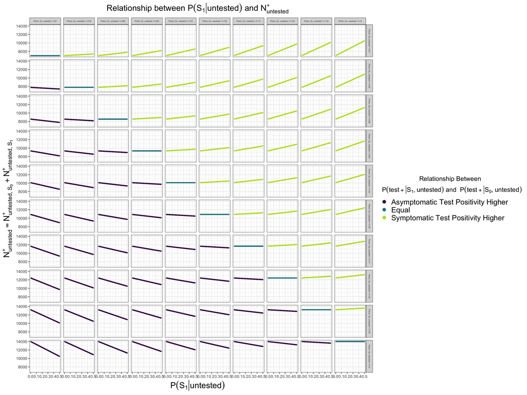

```r
n_untested <- 1e5
p_s_untested <- .01
p_testpos_asymp <- 0.015
p_testpos_symp <-0.09


map_df(seq(0.005, 0.3, length = 1000),
        ~tibble(npos_untested_s0 = n_untested * ( 1- .x) * p_testpos_asymp,
                npos_untested_s1 = n_untested * ( .x) * p_testpos_symp ))


p_symp <- seq(0.005, 0.5, length = 1000)


# df <- expand.grid(p_symp_untested = p_symp,
#                   n_untested= n_untested,
#                   p_s_untested = p_s_untested,
#                   p_testpos_asymp = p_testpos_asymp,
#                   p_testpos_symp = p_testpos_symp) %>%
#   mutate(npos_untested_s0 = n_untested * ( 1- p_symp_untested) * p_testpos_asymp,
#                 npos_untested_s1 = n_untested * ( p_symp_untested) * p_testpos_symp )


df <- expand.grid(p_symp_untested = p_symp,
                  n_untested= n_untested,
                  p_s_untested = p_s_untested,
                  p_testpos_asymp = seq(0.07, .14, length = 10),
                  p_testpos_symp =  seq(0.07, .14, length = 10)) %>%
  mutate(npos_untested_s0 = n_untested * ( 1- p_symp_untested) * p_testpos_asymp,
                npos_untested_s1 = n_untested * ( p_symp_untested) * p_testpos_symp ) %>%
  mutate(asymp_greater = case_when(
    p_testpos_asymp > p_testpos_symp ~ "Asymptomatic Test Positivity Higher",
     p_testpos_asymp < p_testpos_symp ~ "Symptomatic Test Positivity Higher",
    p_testpos_asymp == p_testpos_symp ~ "Equal"))



df %>%
  mutate(p_testpos_asymp_lab = paste0(
    "$P(test + | S_0, untested)$ = ",
    round(p_testpos_asymp, 3)),
              p_testpos_asymp_lab = forcats::fct_reorder(
                p_testpos_asymp_lab, p_testpos_asymp ),
              p_testpos_symp_lab = paste0(
                "$P(test + | S_1, untested)$ = ",
                round(p_testpos_symp, 3)),
              p_testpos_symp_lab = forcats::fct_reorder(
                p_testpos_symp_lab, p_testpos_symp )) %>%
  ggplot(aes(x = p_symp_untested,
             y = npos_untested_s0 + npos_untested_s1,
             color = asymp_greater)) +
  geom_point(size = .5) +
  facet_grid(p_testpos_asymp_lab~p_testpos_symp_lab,
             labeller = as_labeller(latex2exp::TeX, default = label_parsed ) ) +
  viridis::scale_color_viridis(discrete = TRUE, begin =0, end = .9) +
  labs(color = latex2exp::TeX(
    "\\overset{Relationship Between }{ $P(test +| S_1, untested)$ and  $P(test +|S_0,untested)}$"),
    y = latex2exp::TeX("$N^+_{untested} = N^+_{untested,S_0} +  N^+_{untested,S_1}$"),
    x = latex2exp::TeX("$P(S_1|untested)$",),
    title =  latex2exp::TeX("Relationship between $P(S_1|untested)$ and $N^+_{untested}$")) +
  theme_bw() +
  theme(plot.title = element_text(hjust = .5, size = 18),
        axis.title = element_text(size =18),
        strip.text = element_text(size =4),
        legend.text = element_text(size = 16),
        legend.title = element_text(size = 14)) +
  guides(color = guide_legend(override.aes = list(size = 3)))
```

### Changing the Mean of $P(S_1|untested)$, with $P(S_0 | test +, untested)$ Unbounded

```r
params_original <- list(
  alpha_mean = 0.9,
  alpha_sd = 0.04,
  alpha_bounds = c(.8,1),
  beta_mean = .15,
  beta_sd =.09,
  # beta_bounds =  NA,
   beta_bounds = c(0.002, 0.4),
  s_untested_mean = .025,
  s_untested_sd = .0225,
  s_untested_bounds = NA,
  # s_untested_bounds = c(0, 0.15),
  p_s0_pos_mean = .4,
  p_s0_pos_sd = .1225,
  p_s0_pos_bounds = NA,
 # p_s0_pos_bounds = c(.25, .7),
  nsamp = 1e5)


results <- map(seq(.02, .3, by = .05),
     ~ {
       params <- params_original
       params$s_untested_mean <- .x
       # print(params)
       melded <- do.call(get_melded, params)

       title <- paste0("Mean of $P(S_1|untested)$: ", .x)

       melded_long <- reformat_melded(melded_df =  melded$post_melding,
                                      theta_df =  melded$pre_melding,
                                      p_s0_pos_mean = params$p_s0_pos_mean,
                                      p_s0_pos_sd = params$p_s0_pos_sd,
                                      p_s0_pos_bounds = params$p_s0_pos_bounds,
                                      nsamp = params$nsamp)

      corrected <- get_corrected_counts(
                              county_df = covid_county,
                              melded_df = melded$post_melding) %>%
                              mutate(version = "User-specified Priors")


     return(list(title = title, melded_long = melded_long, corrected = corrected))})


lims <- map_df(results, ~
       {
         counts_max <- max(.x$corrected$exp_cases_ub)

         vals <- .x$melded_long %>%
           filter(type == "Induced") %>%
       #    filter(name == "$P(S_0|test+,untested)$") %>%
           pull(value)

          density_est <- density(x = vals)$y

         tibble(title = .x$title,
                counts_max = counts_max,
                density_max = max(density_est))
       })


walk(results, ~{

       p1 <- .x$melded_long %>%
         plot_melded(custom_title = .x$title,
                     nsamp = params_original$nsamp) +
         ylim(0, max(lims$density_max) + .1)

       p2 <- .x$corrected %>%
         plot_corrected() +
         ylim(0, max(lims$counts_max) + max(lims$counts_max)/4)

       plt <- cowplot::plot_grid(p1,p2, nrow = 2, rel_heights = c(2,1),
                                 rel_widths = c(2, 1))

       print(plt)

})
```

[output not shown]

## Changing the Mean of $P(S_0 | test +, untested)$

All parameters left as the original except for $P(S_0 | test +, untested)$, left untruncated for simplicity of changing the mean.

```r
params_original <- list(
  alpha_mean = 0.9,
  alpha_sd = 0.04,
  alpha_bounds = c(.8,1),
 # alpha_bounds=NA,
  beta_mean = .15,
  beta_sd =.09,
 # beta_bounds =  NA,
   beta_bounds = c(0.002, 0.4),
  s_untested_mean = .025,
  s_untested_sd = .0225,
  s_untested_bounds = c(0, 0.15),
  # s_untested_bounds=NA,
  p_s0_pos_mean = .4,
  p_s0_pos_sd = .1225,
  p_s0_pos_bounds = NA,
  # p_s0_pos_bounds = c(.25, .7),
  nsamp = 1e5)


results <- map(seq(.3, .7, by = .1),
     ~ {
       params <- params_original
       params$p_s0_pos_mean <- .x
       # print(params)
       melded <- do.call(get_melded, params)

       title <- paste0("Mean of $P(S_0 | test +, untested)$: ", .x)

      melded_long <- reformat_melded(melded_df =  melded$post_melding,
                                      theta_df =  melded$pre_melding,
                                      p_s0_pos_mean = params$p_s0_pos_mean,
                                      p_s0_pos_sd = params$p_s0_pos_sd,
                                      p_s0_pos_bounds = params$p_s0_pos_bounds,
                                      nsamp = params$nsamp)

      corrected <- get_corrected_counts(
                              county_df = covid_county,
                              melded_df = melded$post_melding) %>%
                              mutate(version = "User-specified Priors")


       return(list(title = title, melded_long = melded_long, corrected = corrected))})


lims <- map_df(results, ~
       {
         counts_max <- max(.x$corrected$exp_cases_ub)

         vals <- .x$melded_long %>%
           filter(type == "Induced") %>%
       #    filter(name == "$P(S_0|test+,untested)$") %>%
           pull(value)

          density_est <- density(x = vals)$y

         tibble(title = .x$title,
                counts_max = counts_max,
                density_max = max(density_est))
       })


walk(results, ~{

       p1 <- .x$melded_long %>%
         plot_melded(custom_title = .x$title,
                     nsamp = params_original$nsamp) +
         ylim(0, max(lims$density_max) + .1)

       p2 <- .x$corrected %>%
         plot_corrected() +
         ylim(0, max(lims$counts_max) + max(lims$counts_max)/4)

       plt <- cowplot::plot_grid(p1,p2, nrow = 2, rel_heights = c(2,1),
                                 rel_widths = c(2, 1))

       print(plt)

})
```

[output not shown]

# Effect of Changing SD

## Changing the SD of $\alpha$

No notable difference here.

```r
params_original <- list(
  alpha_mean = 0.9,
  alpha_sd = 0.04,
  alpha_bounds = c(.8,1),
#  alpha_bounds = NA,
  beta_mean = .15,
  beta_sd =.09,
  beta_bounds = c(0.002, 0.4),
  s_untested_mean = .025,
  s_untested_sd = .0225,
  s_untested_bounds = c(0, 0.15),
  p_s0_pos_mean = .4,
  p_s0_pos_sd = .1225,
  p_s0_pos_bounds = c(.25, .7),
  nsamp = 1e5)


results <- map(seq(.02, .08, by = .02),
     ~ {
       params <- params_original
       params$alpha_sd <- .x
       # print(params)
       melded <- do.call(get_melded, params)

       title <- paste0("SD of ${\\alpha}$: ", .x)

      melded_long <- reformat_melded(melded_df =  melded$post_melding,
                                      theta_df =  melded$pre_melding,
                                      p_s0_pos_mean = params$p_s0_pos_mean,
                                      p_s0_pos_sd = params$p_s0_pos_sd,
                                      p_s0_pos_bounds = params$p_s0_pos_bounds,
                                      nsamp = params$nsamp)

      corrected <- get_corrected_counts(
                              county_df = covid_county,
                              melded_df = melded$post_melding) %>%
                              mutate(version = "User-specified Priors")


     return(list(title = title, melded_long = melded_long, corrected = corrected))})


lims <- map_df(results, ~
       {
         counts_max <- max(.x$corrected$exp_cases_ub)

         vals <- .x$melded_long %>%
           filter(type == "Induced") %>%
       #    filter(name == "$P(S_0|test+,untested)$") %>%
           pull(value)

          density_est <- density(x = vals)$y

         tibble(title = .x$title,
                counts_max = counts_max,
                density_max = max(density_est))
       })


walk(results, ~{

       p1 <- .x$melded_long %>%
         plot_melded(custom_title = .x$title,
                     nsamp = params_original$nsamp) +
         ylim(0, max(lims$density_max) + .1)

       p2 <- .x$corrected %>%
         plot_corrected() +
         ylim(0, max(lims$counts_max) + max(lims$counts_max)/4)

       plt <- cowplot::plot_grid(p1,p2, nrow = 2, rel_heights = c(2,1),
                                 rel_widths = c(2, 1))

       print(plt)

})
```

[output not shown]

## Changing the SD of $\beta$

```r
params_original <- list(
  alpha_mean = 0.9,
  alpha_sd = 0.04,
  alpha_bounds = c(.8,1),
#  alpha_bounds = NA,
  beta_mean = .15,
  beta_sd =.09,
  beta_bounds = c(0.002, 0.4),
  s_untested_mean = .025,
  s_untested_sd = .0225,
  s_untested_bounds = c(0, 0.15),
  p_s0_pos_mean = .4,
  p_s0_pos_sd = .1225,
  p_s0_pos_bounds = c(.25, .7),
  nsamp = 1e5)


results <- map(seq(.05, .15, by = .03),
     ~ {
       params <- params_original
       params$beta_sd <- .x
       # print(params)
       melded <- do.call(get_melded, params)

       title <- paste0("SD of ${\\beta}$: ", .x)

       melded_long <- reformat_melded(melded_df =  melded$post_melding,
                                      theta_df =  melded$pre_melding,
                                      p_s0_pos_mean = params$p_s0_pos_mean,
                                      p_s0_pos_sd = params$p_s0_pos_sd,
                                      p_s0_pos_bounds = params$p_s0_pos_bounds,
                                      nsamp = params$nsamp)

      corrected <- get_corrected_counts(
                              county_df = covid_county,
                              melded_df = melded$post_melding) %>%
                              mutate(version = "User-specified Priors")


    return(list(title = title, melded_long = melded_long, corrected = corrected))})


lims <- map_df(results, ~
       {
         counts_max <- max(.x$corrected$exp_cases_ub)

         vals <- .x$melded_long %>%
           filter(type == "Induced") %>%
       #    filter(name == "$P(S_0|test+,untested)$") %>%
           pull(value)

          density_est <- density(x = vals)$y

         tibble(title = .x$title,
                counts_max = counts_max,
                density_max = max(density_est))
       })


walk(results, ~{

       p1 <- .x$melded_long %>%
         plot_melded(custom_title = .x$title,
                     nsamp = params_original$nsamp) +
         ylim(0, max(lims$density_max) + .1)

       p2 <- .x$corrected %>%
         plot_corrected() +
         ylim(0, max(lims$counts_max) + max(lims$counts_max)/4)

       plt <- cowplot::plot_grid(p1,p2, nrow = 2, rel_heights = c(2,1),
                                 rel_widths = c(2, 1))

       print(plt)

})
```

[output not shown]

## Changing the SD of $P(S_1|untested)$

```r
params_original <- list(
  alpha_mean = 0.9,
  alpha_sd = 0.04,
  alpha_bounds = c(.8,1),
#  alpha_bounds = NA,
  beta_mean = .15,
  beta_sd =.09,
  beta_bounds = c(0.002, 0.4),
  s_untested_mean = .025,
  s_untested_sd = .0225,
  s_untested_bounds = c(0, 0.15),
  p_s0_pos_mean = .4,
  p_s0_pos_sd = .1225,
  p_s0_pos_bounds = c(.25, .7),
  nsamp = 1e5)


results <- map(seq(.01, .04, by = .005),
     ~ {
       params <- params_original
       params$s_untested_sd <- .x
       # print(params)
       melded <- do.call(get_melded, params)

       title <- paste0("SD of $P(S_1|untested)$: ", .x)

       melded_long <- reformat_melded(melded_df =  melded$post_melding,
                                      theta_df =  melded$pre_melding,
                                      p_s0_pos_mean = params$p_s0_pos_mean,
                                      p_s0_pos_sd = params$p_s0_pos_sd,
                                      p_s0_pos_bounds = params$p_s0_pos_bounds,
                                      nsamp = params$nsamp)

      corrected <- get_corrected_counts(
                              county_df = covid_county,
                              melded_df = melded$post_melding) %>%
                              mutate(version = "User-specified Priors")


   return(list(title = title, melded_long = melded_long, corrected = corrected))})


lims <- map_df(results, ~
       {
         counts_max <- max(.x$corrected$exp_cases_ub)

         vals <- .x$melded_long %>%
           filter(type == "Induced") %>%
       #    filter(name == "$P(S_0|test+,untested)$") %>%
           pull(value)

          density_est <- density(x = vals)$y

         tibble(title = .x$title,
                counts_max = counts_max,
                density_max = max(density_est))
       })


walk(results, ~{

       p1 <- .x$melded_long %>%
         plot_melded(custom_title = .x$title,
                     nsamp = params_original$nsamp) +
         ylim(0, max(lims$density_max) + .1)

       p2 <- .x$corrected %>%
         plot_corrected() +
         ylim(0, max(lims$counts_max) + max(lims$counts_max)/4)

       plt <- cowplot::plot_grid(p1,p2, nrow = 2, rel_heights = c(2,1),
                                 rel_widths = c(2, 1))

       print(plt)

})
```

[output not shown]

## Changing the SD of $P(S_0|test +, untested)$

```r
params_original <- list(
  alpha_mean = 0.9,
  alpha_sd = 0.04,
  alpha_bounds = c(.8,1),
#  alpha_bounds = NA,
  beta_mean = .15,
  beta_sd =.09,
  beta_bounds = c(0.002, 0.4),
  s_untested_mean = .025,
  s_untested_sd = .0225,
  s_untested_bounds = c(0, 0.15),
  p_s0_pos_mean = .4,
  p_s0_pos_sd = .1225,
  p_s0_pos_bounds = c(.25, .7),
  nsamp = 1e5)


results <- map(seq(.1, .16, by = .02),
     ~ {
       params <- params_original
       params$p_s0_pos_sd <- .x
       # print(params)
       melded <- do.call(get_melded, params)

       title <- paste0("SD of ${P(S_0|untested,test+)}$: ", .x)

       melded_long <- reformat_melded(melded_df =  melded$post_melding,
                                      theta_df =  melded$pre_melding,
                                      p_s0_pos_mean = params$p_s0_pos_mean,
                                      p_s0_pos_sd = params$p_s0_pos_sd,
                                      p_s0_pos_bounds = params$p_s0_pos_bounds,
                                      nsamp = params$nsamp)

      corrected <- get_corrected_counts(
                              county_df = covid_county,
                              melded_df = melded$post_melding) %>%
                              mutate(version = "User-specified Priors")


        return(list(title = title, melded_long = melded_long, corrected = corrected))})


lims <- map_df(results, ~
       {
         counts_max <- max(.x$corrected$exp_cases_ub)

         vals <- .x$melded_long %>%
           filter(type == "Induced") %>%
       #    filter(name == "$P(S_0|test+,untested)$") %>%
           pull(value)

          density_est <- density(x = vals)$y

         tibble(title = .x$title,
                counts_max = counts_max,
                density_max = max(density_est))
       })


walk(results, ~{

       p1 <- .x$melded_long %>%
         plot_melded(custom_title = .x$title,
                     nsamp = params_original$nsamp) +
         ylim(0, max(lims$density_max) + .1)

       p2 <- .x$corrected %>%
         plot_corrected() +
         ylim(0, max(lims$counts_max) + max(lims$counts_max)/4)

       plt <- cowplot::plot_grid(p1,p2, nrow = 2, rel_heights = c(2,1),
                                 rel_widths = c(2, 1))

       print(plt)

})
```

[output not shown]

## Changing the SD of $P(S_0|test +, untested)$, Unbounded

```r
params_original <- list(
  alpha_mean = 0.9,
  alpha_sd = 0.04,
  alpha_bounds = c(.8,1),
#  alpha_bounds = NA,
  beta_mean = .15,
  beta_sd =.09,
  beta_bounds = c(0.002, 0.4),
  s_untested_mean = .025,
  s_untested_sd = .0225,
  s_untested_bounds = c(0, 0.15),
  p_s0_pos_mean = .4,
  p_s0_pos_sd = .1225,
  p_s0_pos_bounds = NA,
 # p_s0_pos_bounds = c(.25, .7),
  nsamp = 1e5)


results <- map(seq(.1, .16, by = .02),
     ~ {
       params <- params_original
       params$p_s0_pos_sd <- .x
       # print(params)
       melded <- do.call(get_melded, params)

       title <- paste0("SD of ${P(S_0|untested,test+)}$: ", .x)

       melded_long <- reformat_melded(melded_df =  melded$post_melding,
                                      theta_df =  melded$pre_melding,
                                      p_s0_pos_mean = params$p_s0_pos_mean,
                                      p_s0_pos_sd = params$p_s0_pos_sd,
                                      p_s0_pos_bounds = params$p_s0_pos_bounds,
                                      nsamp = params$nsamp)

      corrected <- get_corrected_counts(
                              county_df = covid_county,
                              melded_df = melded$post_melding) %>%
                              mutate(version = "User-specified Priors")


     return(list(title = title, melded_long = melded_long, corrected = corrected))})


lims <- map_df(results, ~
       {
         counts_max <- max(.x$corrected$exp_cases_ub)

         vals <- .x$melded_long %>%
           filter(type == "Induced") %>%
       #    filter(name == "$P(S_0|test+,untested)$") %>%
           pull(value)

          density_est <- density(x = vals)$y

         tibble(title = .x$title,
                counts_max = counts_max,
                density_max = max(density_est))
       })


walk(results, ~{

       p1 <- .x$melded_long %>%
         plot_melded(custom_title = .x$title,
                     nsamp = params_original$nsamp) +
         ylim(0, max(lims$density_max) + .1)

       p2 <- .x$corrected %>%
         plot_corrected() +
         ylim(0, max(lims$counts_max) + max(lims$counts_max)/4)

       plt <- cowplot::plot_grid(p1,p2, nrow = 2, rel_heights = c(2,1),
                                 rel_widths = c(2, 1))

       print(plt)

})
```

[output not shown]

# Effect of Truncation

## Truncation of $\beta$

### Changing Lower Bound, Leaving Upper Untruncated

Observations:

- Increasing the lower bound of $\beta$ corresponds to an increased lower bound of $P(S_0|untested,test+)$ in the melded distribution
- We can see the difference mainly in the melded distribution rather than the induced distribution

```r
results <- map(seq(0, .15, by = .03),
     ~ {
       params <- params_original
       params$beta_bounds <- c(.x,1)
       # print(params)
       melded <- do.call(get_melded, params)

       title <- paste0("Lower Bound of $\\beta$: ", .x)

      melded_long <- reformat_melded(melded_df =  melded$post_melding,
                                      theta_df =  melded$pre_melding,
                                      p_s0_pos_mean = params$p_s0_pos_mean,
                                      p_s0_pos_sd = params$p_s0_pos_sd,
                                      p_s0_pos_bounds = params$p_s0_pos_bounds,
                                      nsamp = params$nsamp)

      corrected <- get_corrected_counts(
                              county_df = covid_county,
                              melded_df = melded$post_melding) %>%
                              mutate(version = "User-specified Priors")


   return(list(title = title, melded_long = melded_long, corrected = corrected))})


lims <- map_df(results, ~
       {
         counts_max <- max(.x$corrected$exp_cases_ub)

         vals <- .x$melded_long %>%
           filter(type == "Induced") %>%
       #    filter(name == "$P(S_0|test+,untested)$") %>%
           pull(value)

          density_est <- density(x = vals)$y

         tibble(title = .x$title,
                counts_max = counts_max,
                density_max = max(density_est))
       })


walk(results, ~{

       p1 <- .x$melded_long %>%
         plot_melded(custom_title = .x$title,
                     nsamp = params_original$nsamp) +
         ylim(0, max(lims$density_max) + .1)

       p2 <- .x$corrected %>%
         plot_corrected() +
         ylim(0, max(lims$counts_max) + max(lims$counts_max)/4)

       plt <- cowplot::plot_grid(p1,p2, nrow = 2, rel_heights = c(2,1),
                                 rel_widths = c(2, 1))

       print(plt)

})
```

[output not shown]

### Changing Upper Bound, Leaving Lower Untruncated

```r
params_original <- list(
  alpha_mean = 0.9,
  alpha_sd = 0.04,
  alpha_bounds = c(.8,1),
  beta_mean = .15,
  beta_sd =.09,
#  beta_bounds =  NA,
  beta_bounds = c(0.002, 0.4),
  s_untested_mean = .025,
  s_untested_sd = .0225,
  s_untested_bounds = c(0, 0.15),
  p_s0_pos_mean = .4,
  p_s0_pos_sd = .1225,
  p_s0_pos_bounds = c(.25, .7),
  nsamp = 1e5)


results <- map(seq(.2, .9, by = .1),
     ~ {
       params <- params_original
       params$beta_bounds <- c(0,.x)
       # print(params)
       melded <- do.call(get_melded, params)

       title <- paste0("Upper Bound of $\\beta$: ", .x)

      melded_long <- reformat_melded(melded_df =  melded$post_melding,
                                      theta_df =  melded$pre_melding,
                                      p_s0_pos_mean = params$p_s0_pos_mean,
                                      p_s0_pos_sd = params$p_s0_pos_sd,
                                      p_s0_pos_bounds = params$p_s0_pos_bounds,
                                      nsamp = params$nsamp)

      corrected <- get_corrected_counts(
                              county_df = covid_county,
                              melded_df = melded$post_melding) %>%
                              mutate(version = "User-specified Priors")


         return(list(title = title, melded_long = melded_long, corrected = corrected))})


lims <- map_df(results, ~
       {
         counts_max <- max(.x$corrected$exp_cases_ub)

         vals <- .x$melded_long %>%
           filter(type == "Induced") %>%
       #    filter(name == "$P(S_0|test+,untested)$") %>%
           pull(value)

          density_est <- density(x = vals)$y

         tibble(title = .x$title,
                counts_max = counts_max,
                density_max = max(density_est))
       })


walk(results, ~{

       p1 <- .x$melded_long %>%
         plot_melded(custom_title = .x$title,
                     nsamp = params_original$nsamp) +
         ylim(0, max(lims$density_max) + .1)

       p2 <- .x$corrected %>%
         plot_corrected() +
         ylim(0, max(lims$counts_max) + max(lims$counts_max)/4)

       plt <- cowplot::plot_grid(p1,p2, nrow = 2, rel_heights = c(2,1),
                                 rel_widths = c(2, 1))

       print(plt)

})
```

[output not shown]

## Truncation of $\alpha$

### Changing Lower Bound, Leaving Upper Untruncated

```r
params_original <- list(
  alpha_mean = 0.9,
  alpha_sd = 0.04,
  alpha_bounds = c(.8,1),
  beta_mean = .15,
  beta_sd =.09,
#  beta_bounds =  NA,
  beta_bounds = c(0.002, 0.4),
  s_untested_mean = .025,
  s_untested_sd = .0225,
  s_untested_bounds = c(0, 0.15),
  p_s0_pos_mean = .4,
  p_s0_pos_sd = .1225,
  p_s0_pos_bounds = c(.25, .7),
  nsamp = 1e5)



results <- map(seq(0, .8, by = .2),
     ~ {
       params <- params_original
       params$alpha_bounds <- c(.x,Inf)
       # print(params)
       melded <- do.call(get_melded, params)

       title <- paste0("Lower Bound of $\\alpha$: ", .x)

       melded_long <- reformat_melded(melded_df =  melded$post_melding,
                                      theta_df =  melded$pre_melding,
                                      p_s0_pos_mean = params$p_s0_pos_mean,
                                      p_s0_pos_sd = params$p_s0_pos_sd,
                                      p_s0_pos_bounds = params$p_s0_pos_bounds,
                                      nsamp = params$nsamp)

      corrected <- get_corrected_counts(
                              county_df = covid_county,
                              melded_df = melded$post_melding) %>%
                              mutate(version = "User-specified Priors")


        return(list(title = title, melded_long = melded_long, corrected = corrected))})


lims <- map_df(results, ~
       {
         counts_max <- max(.x$corrected$exp_cases_ub)

         vals <- .x$melded_long %>%
           filter(type == "Induced") %>%
       #    filter(name == "$P(S_0|test+,untested)$") %>%
           pull(value)

          density_est <- density(x = vals)$y

         tibble(title = .x$title,
                counts_max = counts_max,
                density_max = max(density_est))
       })


walk(results, ~{

       p1 <- .x$melded_long %>%
         plot_melded(custom_title = .x$title,
                     nsamp = params_original$nsamp) +
         ylim(0, max(lims$density_max) + .1)

       p2 <- .x$corrected %>%
         plot_corrected() +
         ylim(0, max(lims$counts_max) + max(lims$counts_max)/4)

       plt <- cowplot::plot_grid(p1,p2, nrow = 2, rel_heights = c(2,1),
                                 rel_widths = c(2, 1))

       print(plt)

})
```

[output not shown]

### Changing Upper Bound, Leaving Lower Untruncated

```r
params_original <- list(
  alpha_mean = 0.9,
  alpha_sd = 0.04,
  alpha_bounds = c(.8,1),
  beta_mean = .15,
  beta_sd =.09,
#  beta_bounds =  NA,
  beta_bounds = c(0.002, 0.4),
  s_untested_mean = .025,
  s_untested_sd = .0225,
  s_untested_bounds = c(0, 0.15),
  p_s0_pos_mean = .4,
  p_s0_pos_sd = .1225,
  p_s0_pos_bounds = c(.25, .7),
  nsamp = 1e5)



results <- map(seq(1, 1.5, by = .1),
     ~ {
       params <- params_original
       params$alpha_bounds <- c(0,.x)
       # print(params)
       melded <- do.call(get_melded, params)

       title <- paste0("Upper Bound of $\\alpha$: ", .x)

       melded_long <- reformat_melded(melded_df =  melded$post_melding,
                                      theta_df =  melded$pre_melding,
                                      p_s0_pos_mean = params$p_s0_pos_mean,
                                      p_s0_pos_sd = params$p_s0_pos_sd,
                                      p_s0_pos_bounds = params$p_s0_pos_bounds,
                                      nsamp = params$nsamp)

      corrected <- get_corrected_counts(
                              county_df = covid_county,
                              melded_df = melded$post_melding) %>%
                              mutate(version = "User-specified Priors")


       return(list(title = title, melded_long = melded_long, corrected = corrected))})


lims <- map_df(results, ~
       {
         counts_max <- max(.x$corrected$exp_cases_ub)

         vals <- .x$melded_long %>%
           filter(type == "Induced") %>%
       #    filter(name == "$P(S_0|test+,untested)$") %>%
           pull(value)

          density_est <- density(x = vals)$y

         tibble(title = .x$title,
                counts_max = counts_max,
                density_max = max(density_est))
       })


walk(results, ~{

       p1 <- .x$melded_long %>%
         plot_melded(custom_title = .x$title,
                     nsamp = params_original$nsamp) +
         ylim(0, max(lims$density_max) + .1)

       p2 <- .x$corrected %>%
         plot_corrected() +
         ylim(0, max(lims$counts_max) + max(lims$counts_max)/4)

       plt <- cowplot::plot_grid(p1,p2, nrow = 2, rel_heights = c(2,1),
                                 rel_widths = c(2, 1))

       print(plt)

})
```

[output not shown]

## Truncation of $P(S_1|untested)$

### Changing Lower Bound, Leaving Upper Untruncated

Observations:

- Increasing lower bound of $P(S_1|untested)$ leads to induced prior in more agreement with direct prior

```r
params_original <- list(
  alpha_mean = 0.9,
  alpha_sd = 0.04,
  alpha_bounds = c(.8,1),
  beta_mean = .15,
  beta_sd =.09,
#  beta_bounds =  NA,
  beta_bounds = c(0.002, 0.4),
  s_untested_mean = .025,
  s_untested_sd = .0225,
  s_untested_bounds = c(0, 0.15),
  p_s0_pos_mean = .4,
  p_s0_pos_sd = .1225,
  p_s0_pos_bounds = c(.25, .7),
  nsamp = 1e5)



results <- map(seq(0, .1, by = .02),
     ~ {
       params <- params_original
       params$s_untested_bounds <- c(.x, Inf)
       # print(params)
       melded <- do.call(get_melded, params)

       title <- paste0("Lower Bound of $P(S_1|untested)$: ", .x)

     melded_long <- reformat_melded(melded_df =  melded$post_melding,
                                      theta_df =  melded$pre_melding,
                                      p_s0_pos_mean = params$p_s0_pos_mean,
                                      p_s0_pos_sd = params$p_s0_pos_sd,
                                      p_s0_pos_bounds = params$p_s0_pos_bounds,
                                      nsamp = params$nsamp)

      corrected <- get_corrected_counts(
                              county_df = covid_county,
                              melded_df = melded$post_melding) %>%
                              mutate(version = "User-specified Priors")


        return(list(title = title, melded_long = melded_long, corrected = corrected))})


lims <- map_df(results, ~
       {
         counts_max <- max(.x$corrected$exp_cases_ub)

         vals <- .x$melded_long %>%
           filter(type == "Induced") %>%
       #    filter(name == "$P(S_0|test+,untested)$") %>%
           pull(value)

          density_est <- density(x = vals)$y

         tibble(title = .x$title,
                counts_max = counts_max,
                density_max = max(density_est))
       })


walk(results, ~{

       p1 <- .x$melded_long %>%
         plot_melded(custom_title = .x$title,
                     nsamp = params_original$nsamp) +
         ylim(0, max(lims$density_max) + .1)

       p2 <- .x$corrected %>%
         plot_corrected() +
         ylim(0, max(lims$counts_max) + max(lims$counts_max)/4)

       plt <- cowplot::plot_grid(p1,p2, nrow = 2, rel_heights = c(2,1),
                                 rel_widths = c(2, 1))

       print(plt)

})
```

[output not shown]

### Changing Upper Bound, Leaving Lower Untruncated

No notable change from changing the upper bound of $P(S_1|untested)$.

```r
params_original <- list(
  alpha_mean = 0.9,
  alpha_sd = 0.04,
  alpha_bounds = c(.8,1),
  beta_mean = .15,
  beta_sd =.09,
  beta_bounds = c(0.002, 0.4),
  s_untested_mean = .025,
  s_untested_sd = .0225,
  s_untested_bounds = c(0, 0.15),
  p_s0_pos_mean = .4,
  p_s0_pos_sd = .1225,
  p_s0_pos_bounds = c(.25, .7),
  nsamp = 1e5)



results <- map(seq(.05, .25, by = .05),
     ~ {
       params <- params_original
       params$s_untested_bounds <- c(0,.x)
       # print(params)
       melded <- do.call(get_melded, params)

       title <- paste0("Upper Bound of $P(S_1|untested)$: ", .x)

        melded_long <- reformat_melded(melded_df =  melded$post_melding,
                                      theta_df =  melded$pre_melding,
                                      p_s0_pos_mean = params$p_s0_pos_mean,
                                      p_s0_pos_sd = params$p_s0_pos_sd,
                                      p_s0_pos_bounds = params$p_s0_pos_bounds,
                                      nsamp = params$nsamp)

      corrected <- get_corrected_counts(
                              county_df = covid_county,
                              melded_df = melded$post_melding) %>%
                              mutate(version = "User-specified Priors")

       return(list(title = title, melded_long = melded_long, corrected = corrected))})


lims <- map_df(results, ~
       {
         counts_max <- max(.x$corrected$exp_cases_ub)

         vals <- .x$melded_long %>%
           filter(type == "Induced") %>%
       #    filter(name == "$P(S_0|test+,untested)$") %>%
           pull(value)

          density_est <- density(x = vals)$y

         tibble(title = .x$title,
                counts_max = counts_max,
                density_max = max(density_est))
       })


walk(results, ~{

       p1 <- .x$melded_long %>%
         plot_melded(custom_title = .x$title,
                     nsamp = params_original$nsamp) +
         ylim(0, max(lims$density_max) + .1)

       p2 <- .x$corrected %>%
         plot_corrected() +
         ylim(0, max(lims$counts_max) + max(lims$counts_max)/4)

       plt <- cowplot::plot_grid(p1,p2, nrow = 2, rel_heights = c(2,1),
                                 rel_widths = c(2, 1))

       print(plt)

})
```

[output not shown]

# Comparing Agreement of Induced Distribution and Direct Distribution ($P(S_0|untested,test+)$ *Bounded*)

```r
compare_induced <- function(
    alpha_mean = 0.9,
    alpha_sd = 0.04,
    alpha_bounds = c(.8,1),
    beta_mean = .15,
    beta_sd =.09,
    beta_bounds = c(0.002, 0.4),
    s_untested_mean = .025,
    s_untested_sd = .0225,
    s_untested_bounds = c(0, 0.15),
    p_s0_pos_mean = .4,
    p_s0_pos_sd = .1225,
    p_s0_pos_bounds = c(.25, .7),
    nsamp = 1e5) {

   params <- as.list(environment())
   print(params)

   theta <- tibble(alpha = sample_gamma_density(nsamp,
                                                mean = alpha_mean,
                                                sd = alpha_sd,
                                                bounds = alpha_bounds),
                    beta= sample_beta_density(nsamp,
                                              mean = beta_mean,
                                              sd = beta_sd,
                                              bounds = beta_bounds),
                    P_S_untested = sample_beta_density(
                      nsamp,
                      mean = s_untested_mean,
                      sd = s_untested_sd,
                      bounds = s_untested_bounds)) %>%
        mutate(phi_induced = est_P_A_testpos(P_S_untested = P_S_untested,
                                             alpha = alpha,
                                             beta=beta))

   rp_s0_pos <- function(x) {

      sample_beta_density(x,
                   mean=p_s0_pos_mean,
                   sd = p_s0_pos_sd,
                   bounds=p_s0_pos_bounds)
   }

   params_title <- paste(names(params),
                         params,
                  sep="=",collapse=",\n" )

   tibble(induced = theta$phi_induced,
          direct = rp_s0_pos(nsamp)) %>%
     pivot_longer(cols=everything()) %>%
     ggplot(aes(x = value, fill = name)) +
     geom_density(alpha = .5)+
     scale_fill_manual(values = c( "#5670BF","#B28542")) +
     theme_bw() +
     theme(plot.title = element_text(size = 14),
           legend.text = element_text(size = 16)) +
     labs(fill= "",
          title = params_title ) +
     guides(fill = guide_legend(keywidth = 2,
                                keyheight =2)) +
     scale_x_continuous(n.breaks = 7)
}
```

```r
params_original <- list(
  alpha_mean = 0.9,
  alpha_sd = 0.04,
  alpha_bounds = NA,
 # alpha_bounds = c(.8,1),
  beta_mean = .15,
  beta_sd =.09,
  beta_bounds = NA,
#  beta_bounds = c(0.002, 0.4),
  s_untested_mean = .025,
  s_untested_sd = .0225,
#  s_untested_bounds = c(0, 0.15),
  s_untested_bounds = NA,
  p_s0_pos_mean = .4,
  p_s0_pos_sd = .1225,
# p_s0_pos_bounds = NA,
  p_s0_pos_bounds = c(.25, .7),
  nsamp = 1e5)



alpha_mean <- seq(.7, 3, length = 4)

beta_mean <- seq(.05, .5, length = 4)

s_untested_mean <- seq(.01, .3, length = 4)


all_combos <- expand.grid(alpha_mean=alpha_mean,
            beta_mean = beta_mean,
            s_untested_mean = s_untested_mean) %>%
  as_tibble()



pwalk(all_combos,
     ~ {
       input <- list(...)
       glimpse(input)
       params <- params_original
       params$alpha_mean <- input$alpha_mean
       params$beta_mean <- input$beta_mean
       params$s_untested_mean <- input$s_untested_mean

       p <- do.call(compare_induced, params)

       print(p)

     })
```

[output not shown]

# Comparing Agreement of Induced Distribution and Direct Distribution ($P(S_0|untested,test+)$ *Unbounded*)

```r
params_original <- list(
  alpha_mean = 0.9,
  alpha_sd = 0.04,
  alpha_bounds = NA,
 # alpha_bounds = c(.8,1),
  beta_mean = .15,
  beta_sd =.09,
  beta_bounds = NA,
#  beta_bounds = c(0.002, 0.4),
  s_untested_mean = .025,
  s_untested_sd = .0225,
#  s_untested_bounds = c(0, 0.15),
  s_untested_bounds = NA,
  p_s0_pos_mean = .4,
  p_s0_pos_sd = .1225,
 p_s0_pos_bounds = NA,
#  p_s0_pos_bounds = c(.25, .7),
  nsamp = 1e5)



alpha_mean <- seq(.7, 3, length = 4)

beta_mean <- seq(.05, .5, length = 4)

s_untested_mean <- seq(.01, .3, length = 4)


all_combos <- expand.grid(alpha_mean=alpha_mean,
            beta_mean = beta_mean,
            s_untested_mean = s_untested_mean) %>%
  as_tibble()



pwalk(all_combos,
     ~ {
       input <- list(...)
       # glimpse(input)
       params <- params_original
       params$alpha_mean <- input$alpha_mean
       params$beta_mean <- input$beta_mean
       params$s_untested_mean <- input$s_untested_mean

       p <- do.call(compare_induced, params)

       print(p)

     })
```

[output not shown]